# gcb_cogsci_outline_old

Hannah

03/20/2023

# Load Data, Scripts, and Packages

#### global parameters

ways to break it down: - have the samples broken down throught, but when we cant, combine the data v. - Results: - overall performance broken down by samples & question type (text report overall accuracy) - reliability (top down categories and) - TM (improve using the pattern of responding to infer components) - across samples - generalizability - sona and prolific to each other (scatter plot by i) - math educaiton history/ performance

A study!

Fig 1: task display methods

Fig 2: multi panel figure (A. test type scatter, B. correlation matrix) ….c. overall performance X question type

Figure 4. [generalizabilty] A. item level scatter plot B. math distribution C. relationship between math and performance report stats between samples here ( ,talk about quesiton type, item in text)

# Study 1 Scope and Related Results

## Overall scores are moderately correlated between tests.

We found that individual participant scores on GGR were moderately predictive of their score on VLAT. Moreover, participants generally did best on Level 1 (“read the data”) and successively less well on Level 2 (“read between the data”) and Level 3 (“read beyond the data”) questions, consistent with a “three-level hierarchy.” However, we did not find evidence for a similar hierarchy among VLAT questions.

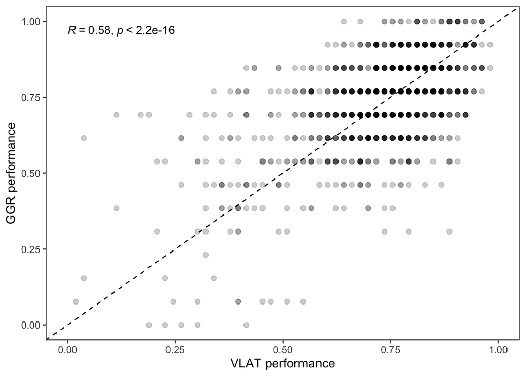

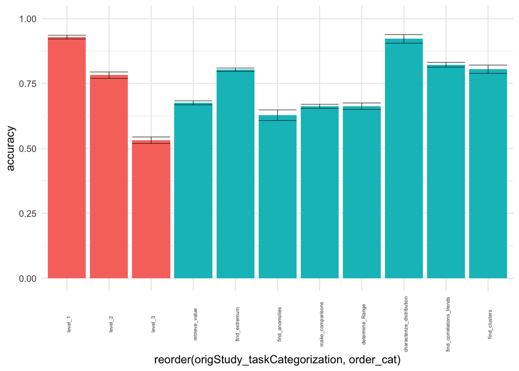

## Inter-item reliability is weak within question type.

Inter-item reliability is weak within question type. Insofar as each question type (e.g., “read beyond the data”) corresponds to a psychologically coherent construct, we predicted that success on these items would be reliable within a participant. However, we instead found that many question types achieved low reliability, including ones that one might have thought to be more straightforward to define (e.g., “retrieve value”).

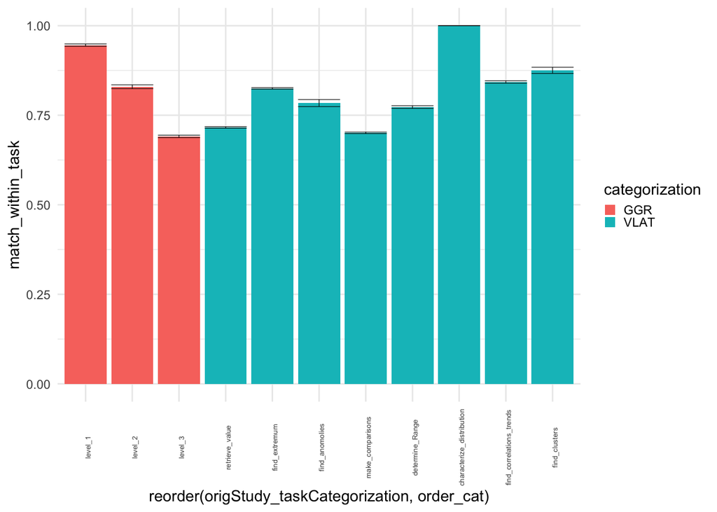

## Scores on specific types of questions were correlated within-test, but weakly between tests.

Scores on specific types of questions were correlated within-test, but weakly between tests. Even questions that you might think were designed to get at the same thing aren’t predictive of each other (i.e., “read the data” in GGR and “retrieve value” in VLAT).

### Predicting accuracy across question type:

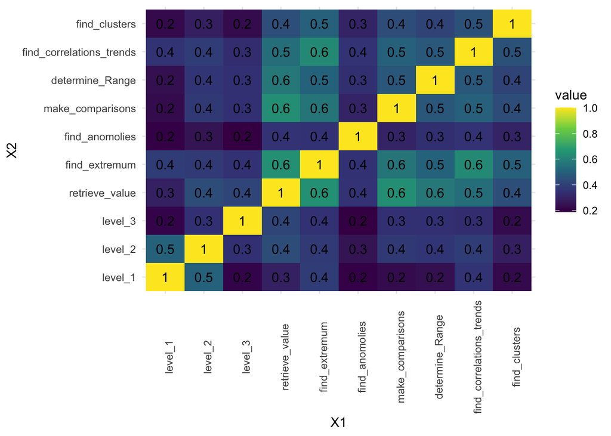

## Topic Model Results (ongoing, high priority)

Data-driven approach to model these data

# Study 2 Scope and Related Results

MOtivated by the same questions, but in a broader, demographically represented sample. Within the broader sample, demographic variables with educational attainment and these assessments.

External validity. Meaningful connection to real-world outcomes and generalizability

what would it mean if the findings didnt generaliz?

Sona study is biased, particular cross section

## Generalizability - Relative performance is remarkably consistent.

Insofar as these assessments have high generalizability and measure graph comprehension, overall performance on these assessments and their respective decomposition structures should be replicated between samples. Performance from the university sample (recruited from the SONA platform) at the task-level, graph-level, and item-level should predict performance from the broder, US-demographically (recruited from the Prolific platform) represented sample.

### Accuracy across samples x overall performance:

What are things that could have happened?

Is the distribution similar, the location of the distribution similar?

Prolific sample sample performs slightly better

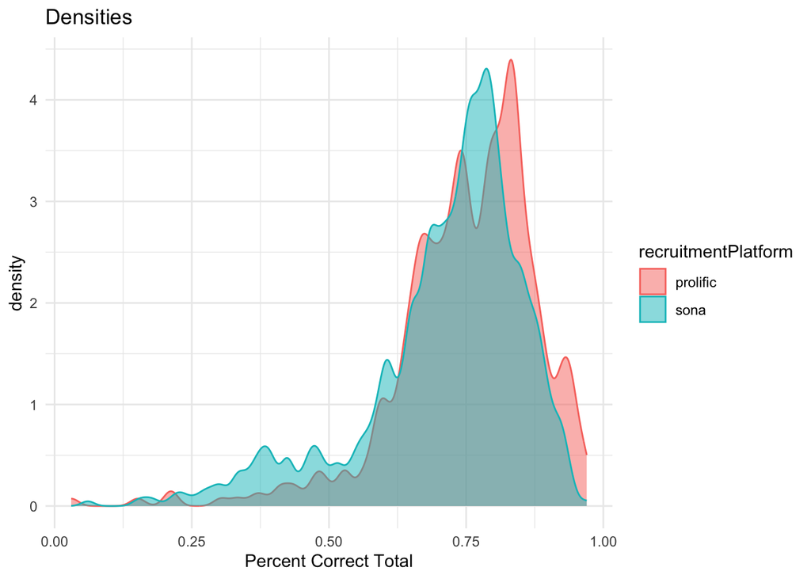

## Accuracy across samples x test type:

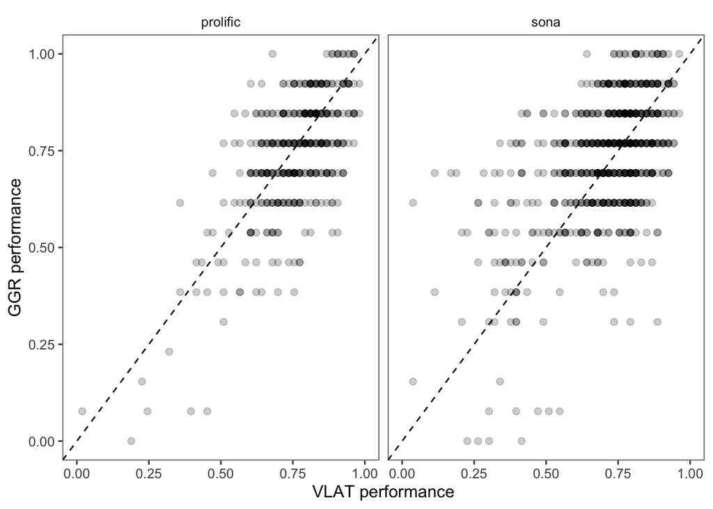

### Accuracy across samples x question type:

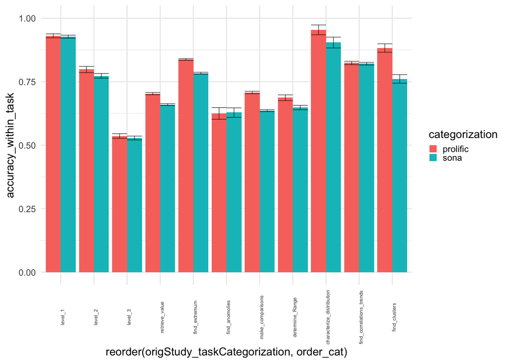

### Accuracy across samples x item: different populations, different profiles of graph competency

[figure not shown]

```
##        mean
## 1 0.7256645
```

## Real-world outcomes - Association between formal math education and overall performance

What is the best word here for math education? # of math classes - amount of math formal education - math education history? - prior mathhistory This could be measuring something else, but if we don’t see the relationship then there is nothing to see.

*TODO:* collect sona demographics for courses

math experience and the samples

does math experience predict performance in the same way across the two samples

could be that prolific is taking more math? no actually?

[figure not shown]

**after thought** the dip in perfromance we just found out if math education predicts performance ### Reliability within question type between samples:

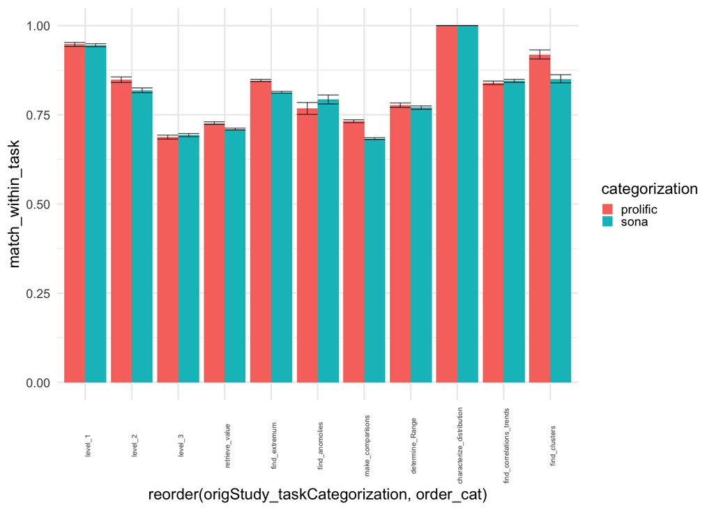

does the way people answer these questions relate to some aspect of their life experiences (math history & sample)

not just how well, but what they are doing with it

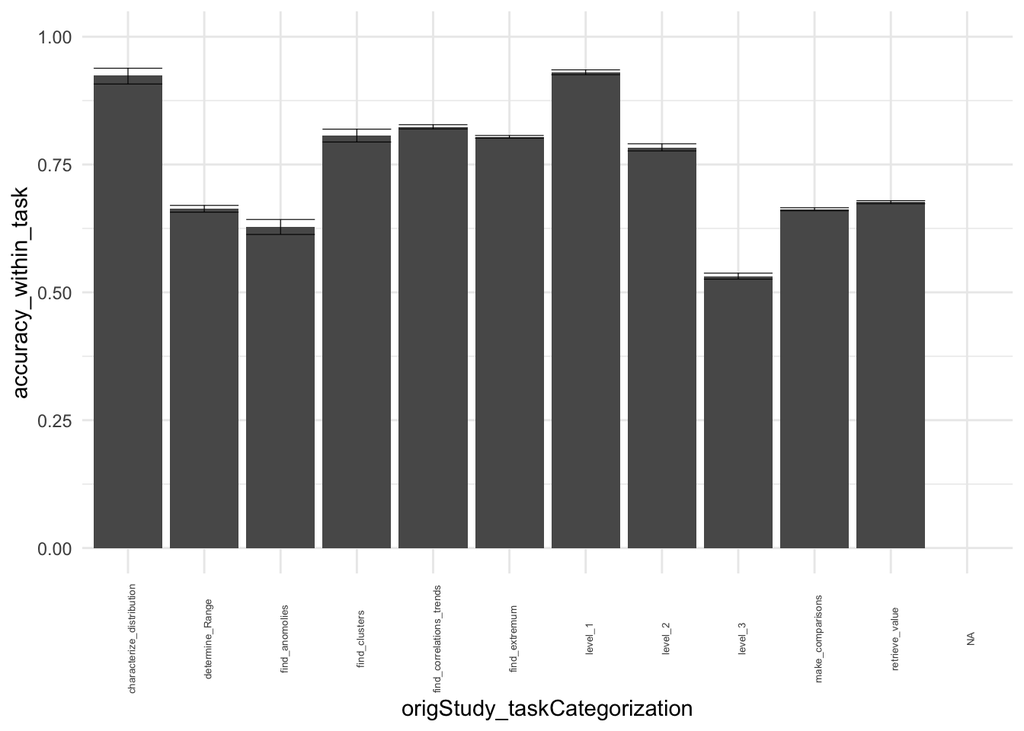

#### Reliability & Stats Similar reliability

##### Question Type:

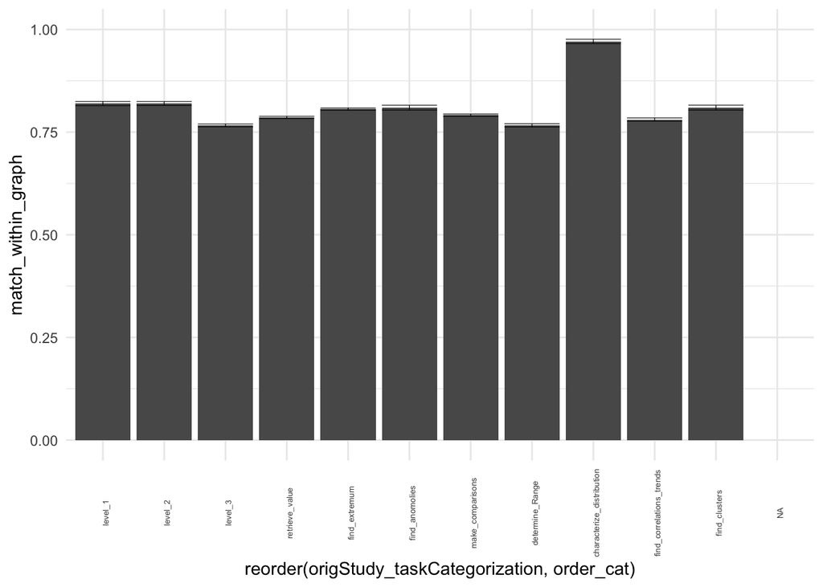

# Extra Graphs

## Accuracy within graph type:

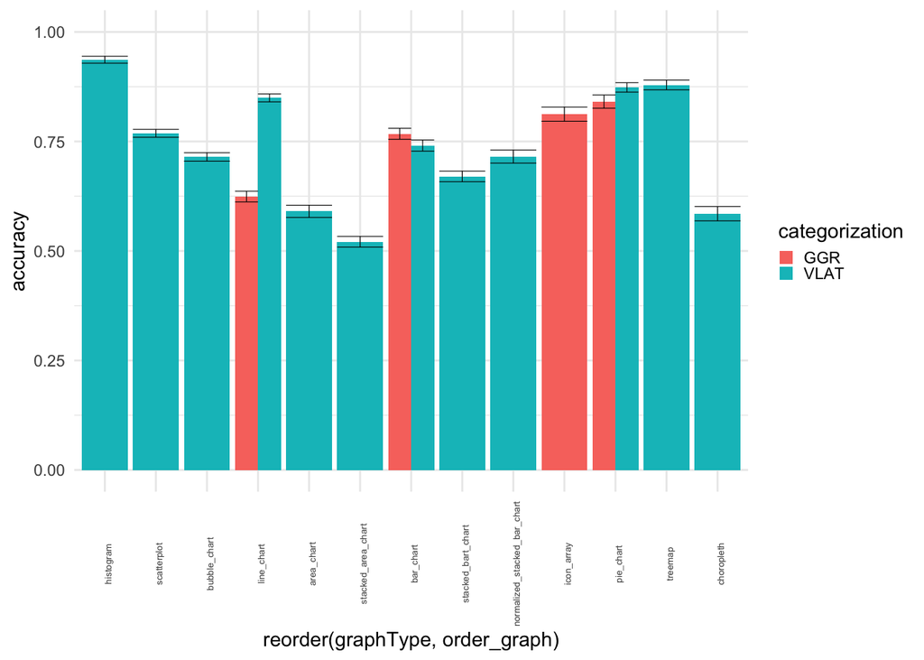

## Predicting accuracy across graph type:

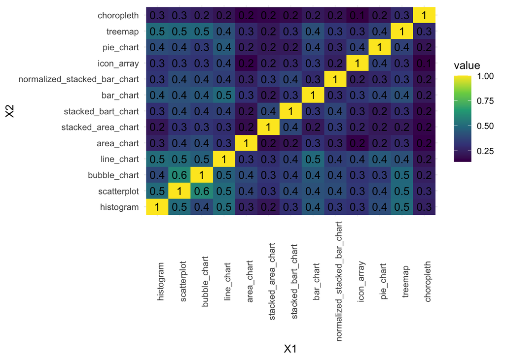